# Homework 2: The Consequences of Frame Selection

Eli Polzer, Mia McReynolds, Matt Futia

06 February 2021

## This exercise links to Module 2.3.3

Submit the completed exercise to us at:

- t.edwards@usu.edu
- eric_tsakiris@fws.gov

## Context

The exercise explores the consequences of frame selection on numerical summaries of predictive variables. The species being explored is [*Pinus edulis* Common piñon](https://www.conifers.org/pi/Pinus_edulis.php). Feel free to refer to the illustrations in Module 2.3.2 for graphical context.

## The Data

- Load **`spp106.soil.Rdata`** and **`spp106.clim.Rdata`** (or import **`spp106.soil.csv`**, **`spp106.clim.csv`**)
- Data in: **`~\sdhmR-V2020.2\data\module02`**

```r
# some libraries
  library(raster)   # FXNS: extent, raster, res, rasterize, values, writeRaster,
                    #       cellFromXY, extract
  library(sf)       # FXNS: st_as_sf, st_as_sfc, st_bbox, st_convex_hull, st_union
                    #       st_buffer, st_read, st_write, st_intersection, st_geometry,
                    #       st_drop_geometry, st_coordinates, st_sf
  library(terra)    # FXNS: as.data.frame, rast, vect
  library(readr)
  library(ggplot2)
  library(dplyr)
  library(tidyr)

#filepaths
  path.root <- "~/University of Vermont/Classes/sdhmR/sdhmR-V2021.1"
  path.mod2 <- paste(path.root, "/data/module02", sep = "")
  path.figs <- paste(path.root, "/powerpoints/figures", sep = "")
  path.gis <- paste(path.root, "/data/gis_layers", sep = "")

#import data
setwd(path.mod2)
spp_soil <- read_csv("spp106.soil.csv")
spp_clim <- read_csv("spp106.clim.csv")
```

## Question #1

- What are the expected consequences in terms of a SDHM classification model if differences between environmental variables measured at presence:absence sites are large vs. small?

Statistically, it’s easier to build a reliable classification model based on environmental variables that vary dramatically between presence and absence sites. Large variation in environmental variables increases the discriminatory power of the model because they can provide a stronger signal:noise ratio. If environmental variables differ by a small amount between presence and absence sites, it’s harder to discriminate between weak differences in species’ environmental preferences and noise (or, natural variation in the data).

However, errors may occur in building SDHMs based on mathematical reasoning and ignoring the biology of the species of interest. If species are finely attuned to environmental factors with smaller variance between presence:absence sites, these factors may be treated as unimportance in the model building process despite their high biological importance.

## Question #2

- How might these differing frames, and their respective variable differences based on the presence or absence of the species, affect:
  - 1. ecological interpretations, and
  - 2. their classification ability, of variables?
1. Ecological interpretations are affected because the frames have different spatial extents and data sources, which can limit research questions and comparisons between sites. Using a modelling frame with a larger spatial extent that covers a greater range of variables allow findings from the model to be extrapolated to a wider range of ecological conditions. Some of the frames were guided by previous research, which should be reflected in the model objectives and interpretation. For example, an SDHM could investigate current tree distribution within the extent of trees documented by Little. Since this SDHM is built from a distribution that these trees were shown to occupy, the range of variables is narrower and will under-represent conditions associated with absence of the species.

Having frames that are much larger than the actual range of a species may cause ecological interpretations to be biased towards environmental factors with large variance rather than factors that are most influential for the habitat use. Alternatively, small frames may exclude observations resulting in a different interpretation of the species’ habitat use.

2. While small differences or changes may indicate that environmental variables are less important in discriminatory analysis, large differences of environmental variables when viewed across differing modeling frames likely indicate an important attribute with enhanced discriminatory power. Classification ability is affected because these frames vary in the range of environmental variables – for example, the dry desert plus Little’s framework has the smallest variation in elevation between presence/absence sites.

## Question #3

- How do you decide which frame – given many competing – is appropriate for SDHM construction?

This question references back to user objectives/intended use. Like variable selection, selection of modeling frame should not be done arbitrarily, as one’s choice may unintentionally aid the production of models that inadequately represent habitats and species distributions and have less predictive power. While a model utilizing higher quality attribute data may be needed to guide decisions with significant consequences, a more simplistic model employing less ‘ideal’ data at a coarser spatial scale may be sufficient for another venture having less significant costs.

You should consider the extent and density of available data sources, as well as the spatial extent to which you want to apply the model.

## Question #4

- Examine variable names and select 3 for all subsequent questions. Identify them below in your answer to this question.

It’s really hard to interpret the names in spp clim, so I’ll use some of the spp soil variables. avc_wtavg may be average water content, weighted average. Clay is the clay % in soil. Frag3 to 10 is a measurement of grain size that shows rock fragments through a No. 10 sieve.

## Question #5

- Run some simple descriptive statistics (ie, $\bar{x}$, $SD$) on the three (3) selected variables from above and compare across frames (where 1=inside frame; 0=outside):
- There are four (4) frames to evaluate:
  - Western U.S. states; this frame is defined as the entire dataframe N
  - **`$dry.domfr`** = all *edulis* within the dry domain
  - **`$SPPRES106.fiafr`** = buffered *edulis* distribution based on FIA data points
  - **`$SPPRES106.cmbfr`** = buffered *edulis* distribution based on FIA data points plus the UNION with [Little’s mapped tree distributions](https://www.fs.fed.us/database/feis/pdfs/Little/aa_SupportingFiles/LittleMaps.html).

```r
western_US_states <- spp_soil %>%
  summarise(mean_awc_wtave = mean(awc_wtave, na.rm=TRUE),
            sd_awc_wtave = sd(awc_wtave, na.rm=TRUE),
          mean_clay = mean(clay, na.rm=TRUE),
          sd_clay = sd(clay, na.rm=TRUE),
          mean_frag3to10 = mean(frag3to10, na.rm=TRUE),
          sd_frag3to10 = sd(frag3to10, na.rm=TRUE))
western_US_states
```

```
## # A tibble: 1 x 6
##   mean_awc_wtave sd_awc_wtave mean_clay sd_clay mean_frag3to10 sd_frag3to10
##            <dbl>        <dbl>     <dbl>   <dbl>          <dbl>        <dbl>
## 1          2844.        2412.      21.3    9.44           6.53         8.10
```

```r
dry_domain <- spp_soil %>%
  filter(dry.domfr==1) %>%
  summarise(mean_awc_wtave = mean(awc_wtave, na.rm=TRUE),
            sd_awc_wtave = sd(awc_wtave, na.rm=TRUE),
          mean_clay = mean(clay, na.rm=TRUE),
          sd_clay = sd(clay, na.rm=TRUE),
          mean_frag3to10 = mean(frag3to10, na.rm=TRUE),
          sd_frag3to10 = sd(frag3to10, na.rm=TRUE))
dry_domain
```

```
## # A tibble: 1 x 6
##   mean_awc_wtave sd_awc_wtave mean_clay sd_clay mean_frag3to10 sd_frag3to10
##            <dbl>        <dbl>     <dbl>   <dbl>          <dbl>        <dbl>
## 1          2915.        2443.      21.2    9.44           6.57         8.17
```

```r
FIA_points <- spp_soil %>%
  filter(SPPRES106.fiafr==1) %>%
  summarise(mean_awc_wtave = mean(awc_wtave, na.rm=TRUE),
            sd_awc_wtave = sd(awc_wtave, na.rm=TRUE),
          mean_clay = mean(clay, na.rm=TRUE),
          sd_clay = sd(clay, na.rm=TRUE),
          mean_frag3to10 = mean(frag3to10, na.rm=TRUE),
          sd_frag3to10 = sd(frag3to10, na.rm=TRUE))
FIA_points
```

```
## # A tibble: 1 x 6
##   mean_awc_wtave sd_awc_wtave mean_clay sd_clay mean_frag3to10 sd_frag3to10
##            <dbl>        <dbl>     <dbl>   <dbl>          <dbl>        <dbl>
## 1          3356.        2565.      21.0    7.16           8.66         9.85
```

```r
FIA_Little_points <- spp_soil %>%
  filter(SPPRES106.cmbfr==1) %>%
  summarise(mean_awc_wtave = mean(awc_wtave, na.rm=TRUE),
            sd_awc_wtave = sd(awc_wtave, na.rm=TRUE),
          mean_clay = mean(clay, na.rm=TRUE),
          sd_clay = sd(clay, na.rm=TRUE),
          mean_frag3to10 = mean(frag3to10, na.rm=TRUE),
          sd_frag3to10 = sd(frag3to10, na.rm=TRUE))
FIA_Little_points
```

```
## # A tibble: 1 x 6
##   mean_awc_wtave sd_awc_wtave mean_clay sd_clay mean_frag3to10 sd_frag3to10
##            <dbl>        <dbl>     <dbl>   <dbl>          <dbl>        <dbl>
## 1          3354.        2573.      20.8    7.22           8.47         9.73
```

The summary values seem very similar over these four spatial extents. I’d suspect that they are not statistically distinguishable, as the mean plus/minus 1 standard deviation overlaps for all three variables.

## Question #6

- Build box plots with the 4 frames by variable for each of your selected variable, ie this will be 3 variables $\times$ 4 different frames.

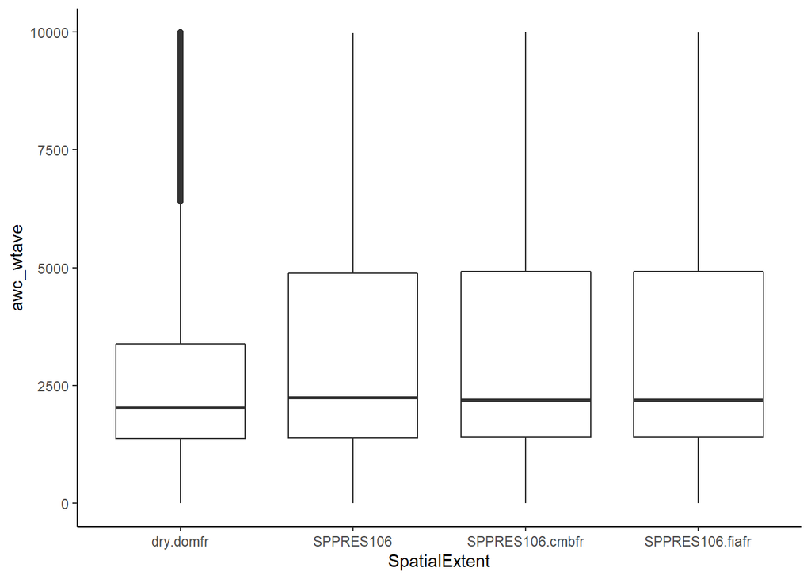

```r
#reshape data for easier plotting
spp_soil_long <-  pivot_longer(spp_soil, cols=SPPRES106:SPPRES106.cmbfr, names_to="SpatialExtent", values_to="PartofSF") %>%
  filter(PartofSF==1)


ggplot(spp_soil_long, aes(x=SpatialExtent, y=awc_wtave)) +
  geom_boxplot() +
  theme_classic()
```

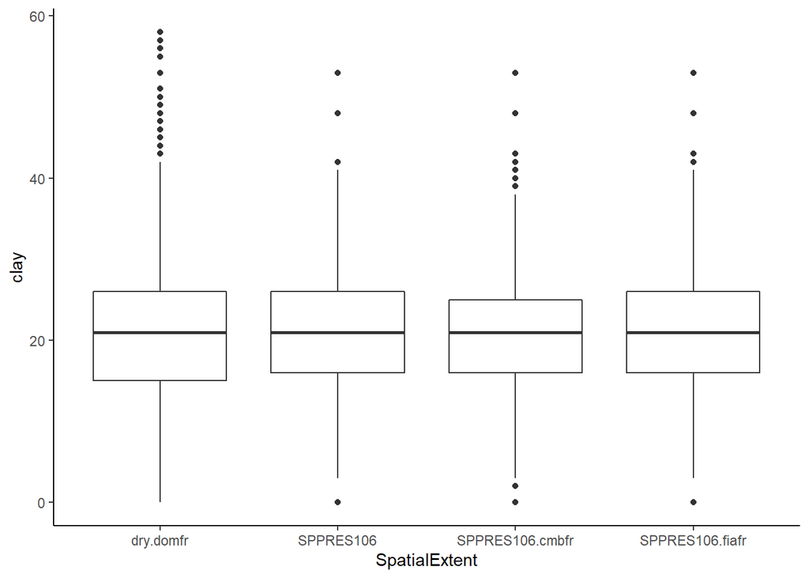

```r
ggplot(spp_soil_long, aes(x=SpatialExtent, y=clay)) +
  geom_boxplot() +
  theme_classic()
```

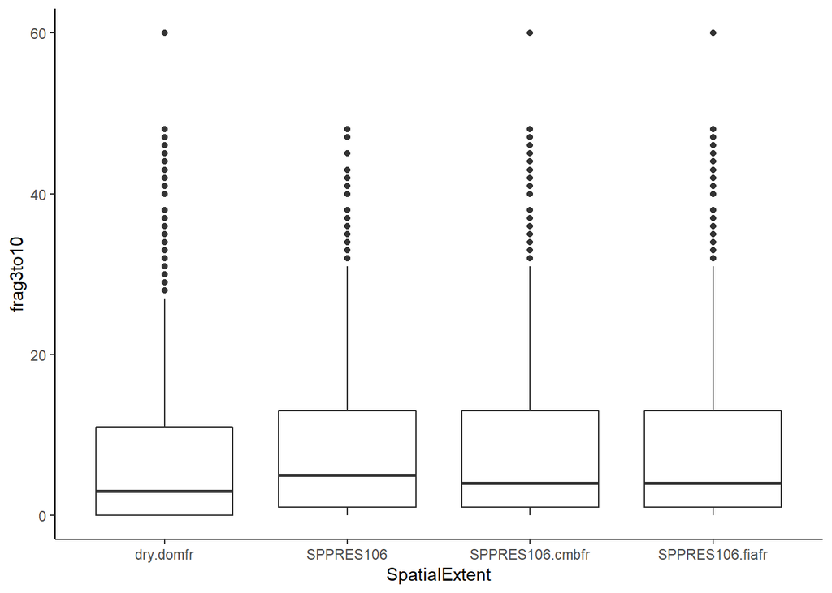

```r
ggplot(spp_soil_long, aes(x=SpatialExtent, y=frag3to10)) +
  geom_boxplot() +
  theme_classic()
```

The distribution of values is very similar for the 4 spatial frames considered. On average, the dry domain is somewhat lower in average water content and mean fragment 3 to 10. However, the overall range and distributions are very similar.

## Question #7:

- Identify which of the variables that subjectively (No statistical tests here, please!Just your Mark I eyeballs.) look as though they would discriminate between presence and absence

Based on the plots above, these three variables would likely not discriminate well between presence and absence, because their values are similar among different spatial extents (or, different concentrations of presence/absence points). The most likely candidates are average water content and mean fragment 3 to 10, since they show slight differences between the dry domain and the smaller region of FIA/Little’s points where the trees are present.